# Introduction to ggplot2

### Changing how geometries look like

We can change how geometries look like in several ways, for example their transparency, colour, shape, etc.

To know which *aesthetic* components can be changed in a particular geometry, look at its help (e.g. `?geom_point`) and look under the “Aesthetics” section of the help page.

For example, because the points in the above graph are quite densely packed, we can change the transparency of the points in our scatterplot using `alpha` (`alpha` varies between 0-1 with zero being transparent and 1 being opaque):

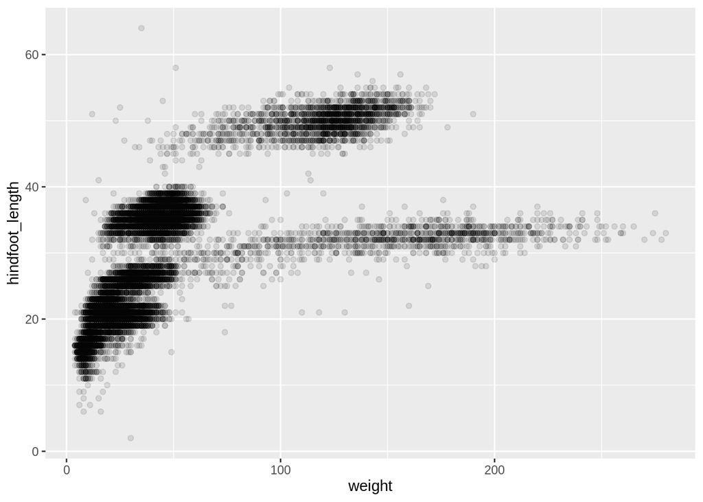

```r
ggplot(data = surveys_nomiss,
       mapping = aes(x = weight, y = hindfoot_length)) +
  geom_point(alpha = 0.1)
```

With this transparency we can see which areas of the graph are more densely occupied with points.

**Exercise**

> Try changing the *size*, *shape* and *colour* of the points (hint: web search “ggplot2 point shapes” to see how to make a triangle)

### Changing aesthetics based on data

In the above exercise we changed the colour of the points by defining it ourselves. However, it would be better if we coloured the points based on a variable of interest.

For example, it’s likely that the clustering of points in our scatterplot is due to differences between genera.

We do this by passing this information to the `colour` *aesthetic* inside the `aes()` function:

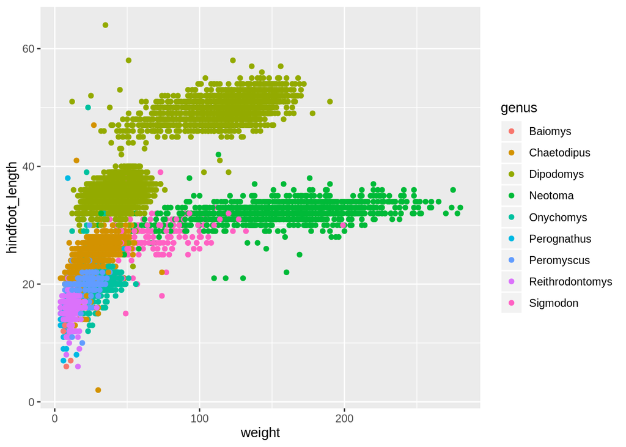

```r
ggplot(data = surveys_nomiss,
       mapping = aes(x = weight, y = hindfoot_length, colour = genus)) +
  geom_point()
```

This illustrates an important distinction between *aesthetics* defined inside or outside of `aes()`:

- if you want the *aesthetic* to change **based on the data** it goes **inside `aes()`**
- if you want to **manually specify** how the geometry should look like, it goes **outside `aes()`**

**Exercise**

> Make a [boxplot](https://www.data-to-viz.com/caveat/boxplot.html) that shows the distribution of `weight` (y-axis) for each `genus` (x-axis). (hint: `geom_boxplot()`)

> **Bonus:** Colour the *inside* of the boxplots by sex

### Multiple geometries

Often, we may want to overlay several geometries on top of each other. For example, add a [violin plot](https://www.data-to-viz.com/graph/violin.html) together with a boxplot so that we get both representations of the data in a single graph.

Let’s start by making a violin plot:

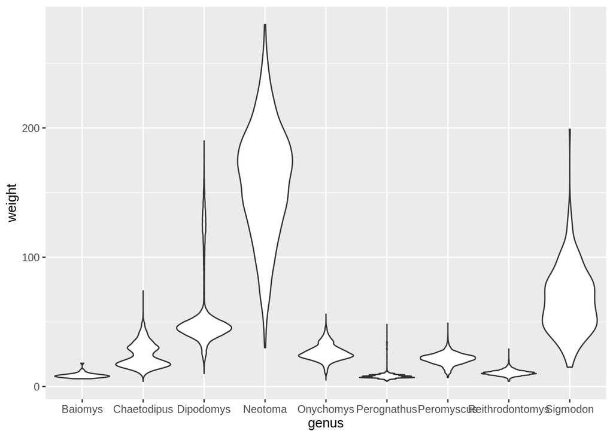

```r
# scale the violins by "width" rather than "area", which is the default
ggplot(surveys_nomiss, aes(x = genus, y = weight)) +
  geom_violin(scale = "width")
```

To layer a boxplot on top of it we “add” (with `+`) another geometry to the graph:

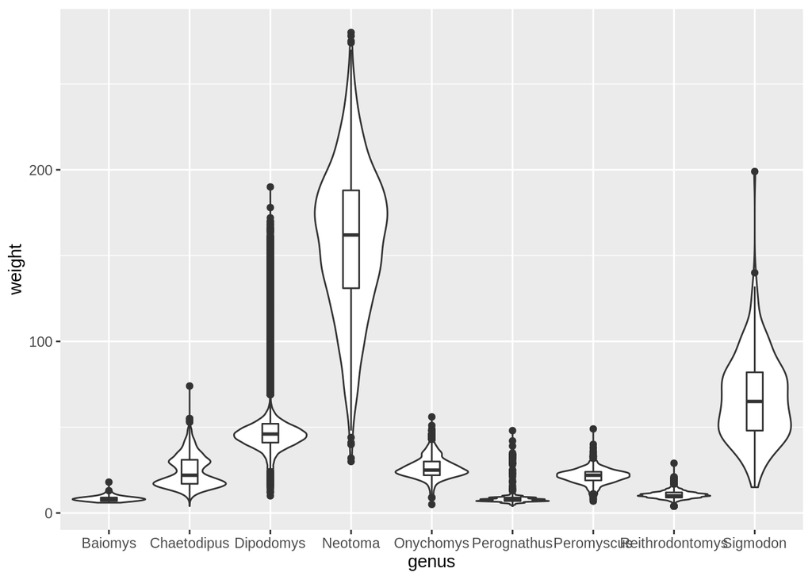

```r
# Make boxplots thinner so the shape of the violins is visible
ggplot(surveys_nomiss, aes(x = genus, y = weight)) +
  geom_violin(scale = "width") +
  geom_boxplot(width = 0.2)
```

The order in which you add the geometries defines the order they are “drawn” on the graph. For example, try swapping their order and see what happens (bonus: try adding transparency to the violin plot)

Notice how we’ve shortened our code by omitting the names of the options `data =` and `mapping =` inside `ggplot()`. Because the data is always the first thing given to `ggplot()` and the mapping is always identified by the function `aes()`, this is often written in the more compact form as we just did.

### Controlling aesthetics in individual geometries

Let’s say that, in the graph above, we wanted to colour the violins by genus, but keep the boxplots without colour.

As we’ve learned, because we want to colour our geometries *based on data*, this goes inside the `aes()` part of the graph:

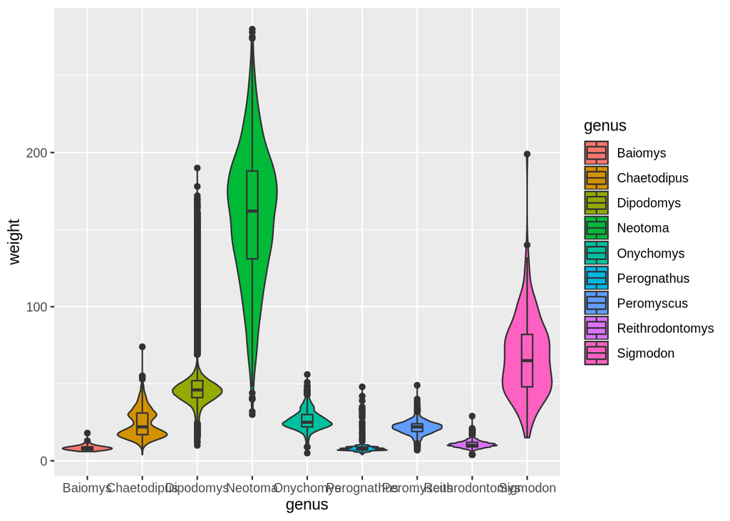

```r
# use the `fill` aesthetic, which colours the **inside** of the geometry
ggplot(surveys_nomiss, aes(x = genus, y = weight, fill = genus)) +
  geom_violin(scale = "width") +
  geom_boxplot(width = 0.2)
```

OK, this is not what we wanted. Both *geometries* (boxplots and violins) got coloured.

It turns out that we can control aesthetics individually in each geometry, using the `aes()` function. Like this:

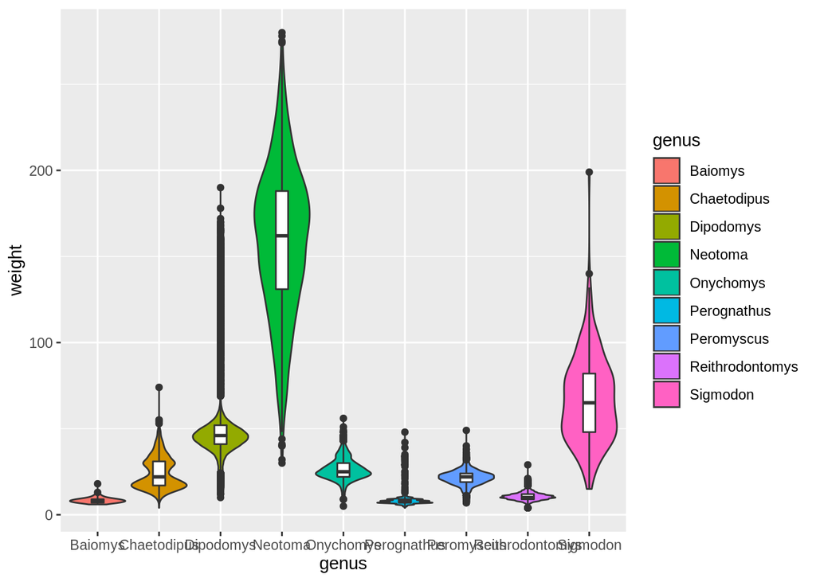

```r
ggplot(surveys_nomiss, aes(x = genus, y = weight)) +
  geom_violin(aes(fill = genus), scale = "width") +
  geom_boxplot(width = 0.2)
```

**Exercise**

> Modify the graph above by colouring the inside of the boxplots by genus and the inside of the violins in grey colour.

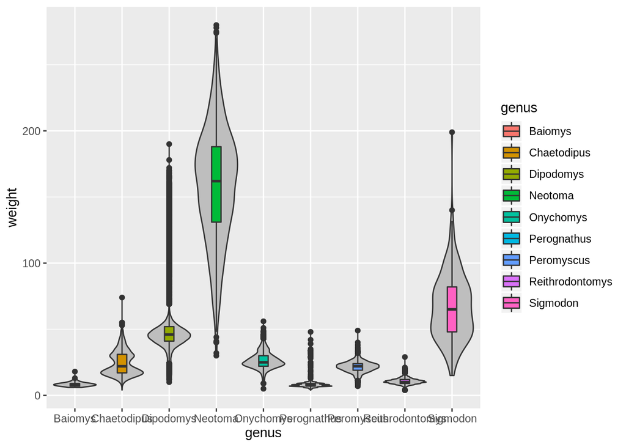

### Facets

You can split your plot into multiple panels by using *facetting*. There are two types of *facet* functions:

- `facet_wrap()` arranges a one-dimensional sequence of panels to fit on one page.
- `facet_grid()` allows you to form a matrix of rows and columns of panels.

Both geometries allow to to specify faceting variables specified with `vars()`. In general: `facet_wrap(facets = vars(facet_variable))` or `facet_grid(rows = vars(row_variable), cols = vars(col_variable))`.

For example, if we want to visualise the scatterplot above split by `genus`:

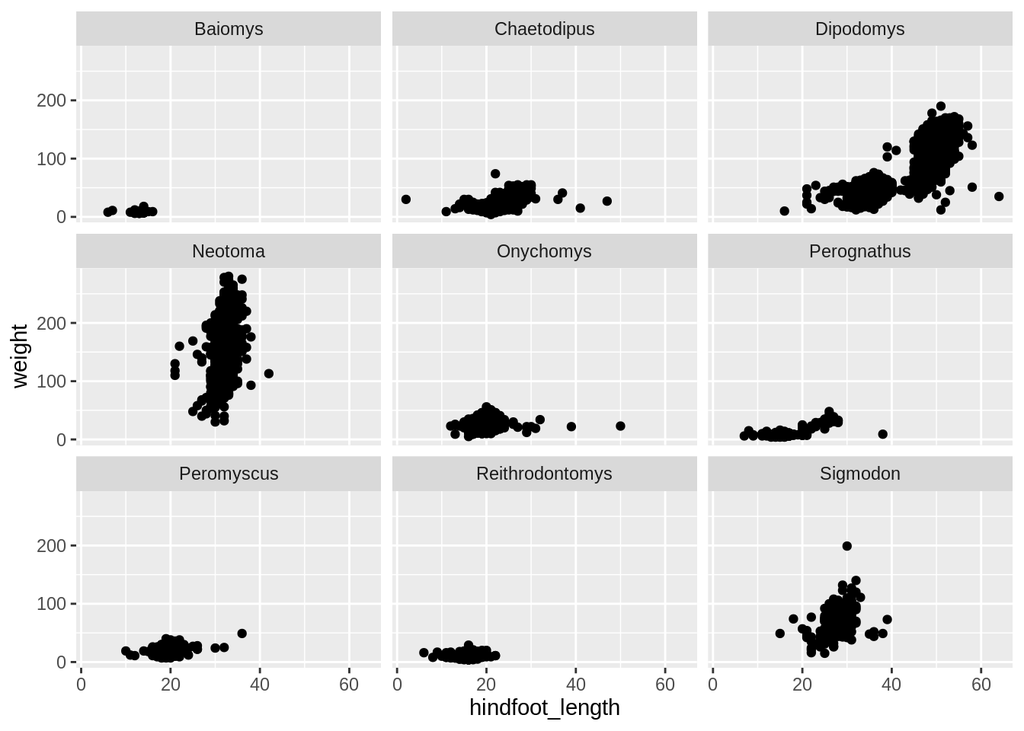

```r
ggplot(surveys_nomiss, aes(hindfoot_length, weight)) +
  geom_point() +
  facet_wrap(facets = vars(genus))
```

If instead we want a *matrix* of facets to display `genus` and `sex`, then we use `facet_grid()`:

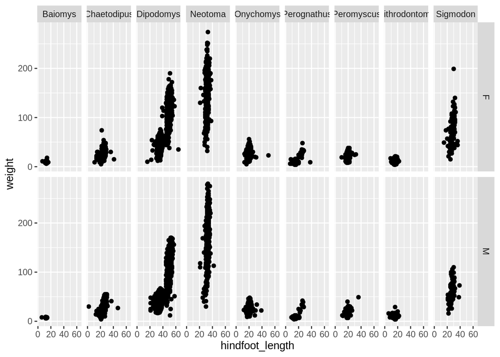

```r
ggplot(surveys_nomiss, aes(hindfoot_length, weight)) +
  geom_point() +
  facet_grid(rows = vars(sex), cols = vars(genus))
```

Finally, with `facet_grid()`, you can organise the panels just by rows or just by columns. Try running this code yourself:

```r
# One column, facet by rows
ggplot(surveys_nomiss,
       mapping = aes(x = hindfoot_length, y = weight)) +
  geom_point() +
  facet_grid(rows = vars(genus))

# One row, facet by column
ggplot(surveys_nomiss,
       mapping = aes(x = hindfoot_length, y = weight)) +
  geom_point() +
  facet_grid(cols = vars(genus))
```

### Modifying scales

Often you want to change how the scales of your plot are defined. In `ggplot2` scales can refer to the `x` and `y` aesthetics, but also to other aesthetics such as `colour`, `shape`, `fill`, etc.

We modify scales using the *scale* family of functions. These functions always follow the following naming convention: `scale_<aesthetic>_<type>`, where:

- `<aesthetic>` refers to the aesthetic for that scale function (e.g. `x`, `y`, `colour`, `fill`, `shape`, etc.)
- `<type>` refers to the type of aesthetic (e.g. `discrete`, `continuous`, `manual`)

Let’s see some examples.

#### Change a continuous axis scale

Taking the graph from the previous exercise we modify the y-axis scale to emphasise the lower weights of our animals:

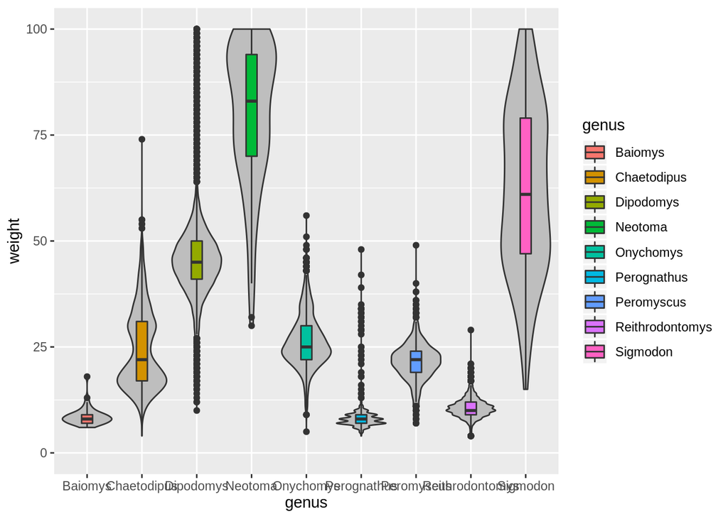

```r
ggplot(surveys_nomiss, aes(x = genus, y = weight)) +
  geom_violin(scale = "width", fill = "grey") +
  geom_boxplot(width = 0.2, aes(fill = genus)) +
  scale_y_continuous(limits = c(0, 100))
```

#### Change a discrete axis scale

Our x-axis is discrete (data are categorical). Let’s, for example, *limit* which categories are shown and in which order:

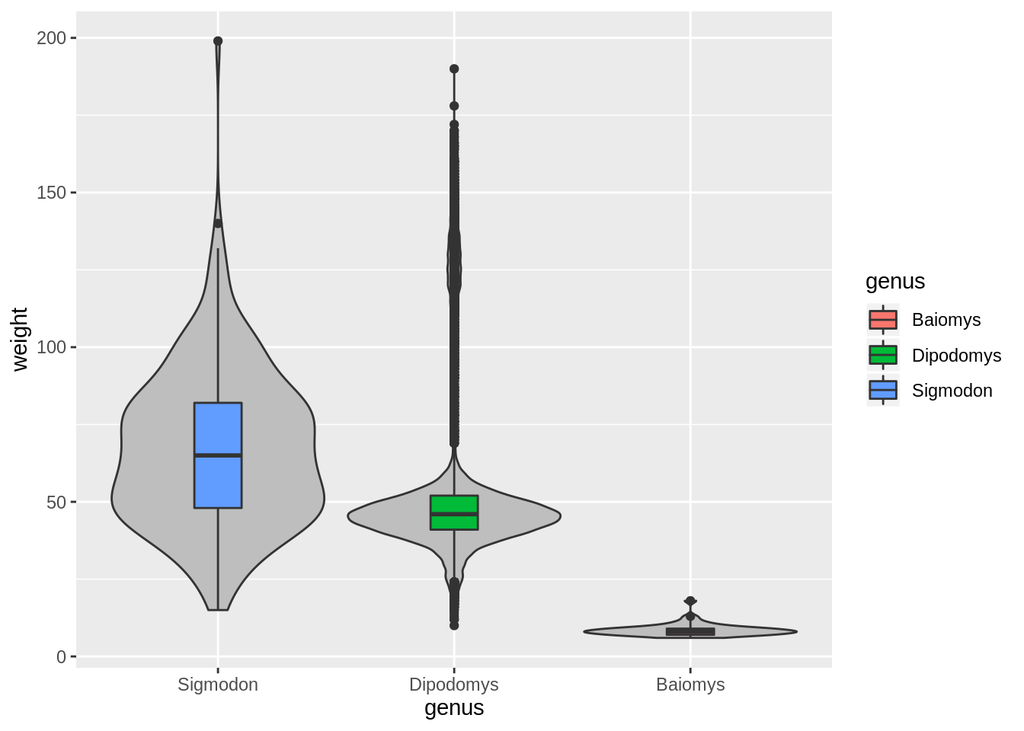

```r
ggplot(surveys_nomiss, aes(x = genus, y = weight)) +
  geom_violin(scale = "width", fill = "grey") +
  geom_boxplot(width = 0.2, aes(fill = genus)) +
  scale_x_discrete(limits = c("Sigmodon", "Dipodomys", "Baiomys"))
```

#### Change categorical colour/fill scales

Taking the previous plot, let’s change the `fill` scale to define custom colours “manually”.

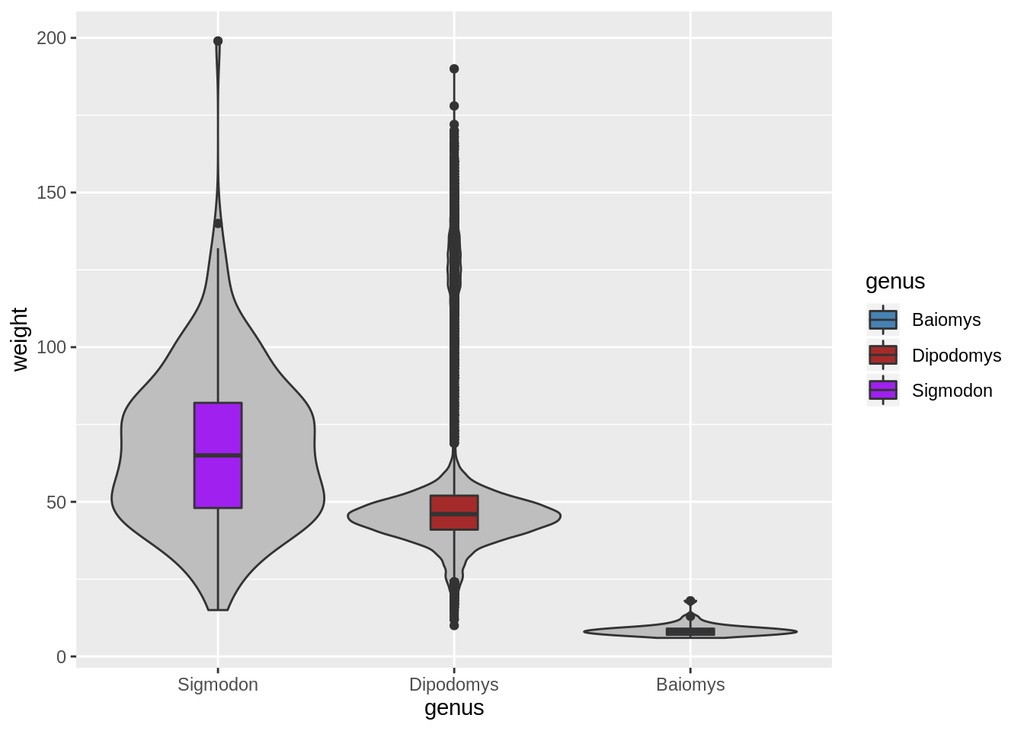

```r
ggplot(surveys_nomiss, aes(x = genus, y = weight)) +
  geom_violin(scale = "width", fill = "grey") +
  geom_boxplot(width = 0.2, aes(fill = genus)) +
  scale_x_discrete(limits = c("Sigmodon", "Dipodomys", "Baiomys")) +
  scale_fill_manual(values = c("Sigmodon" = "purple",
                               "Dipodomys" = "brown",
                               "Baiomys" = "steelblue"))
```

For colour/fill scales there’s a very convenient variant of the `scale` function (“brewer”) that has some pre-defined palettes:

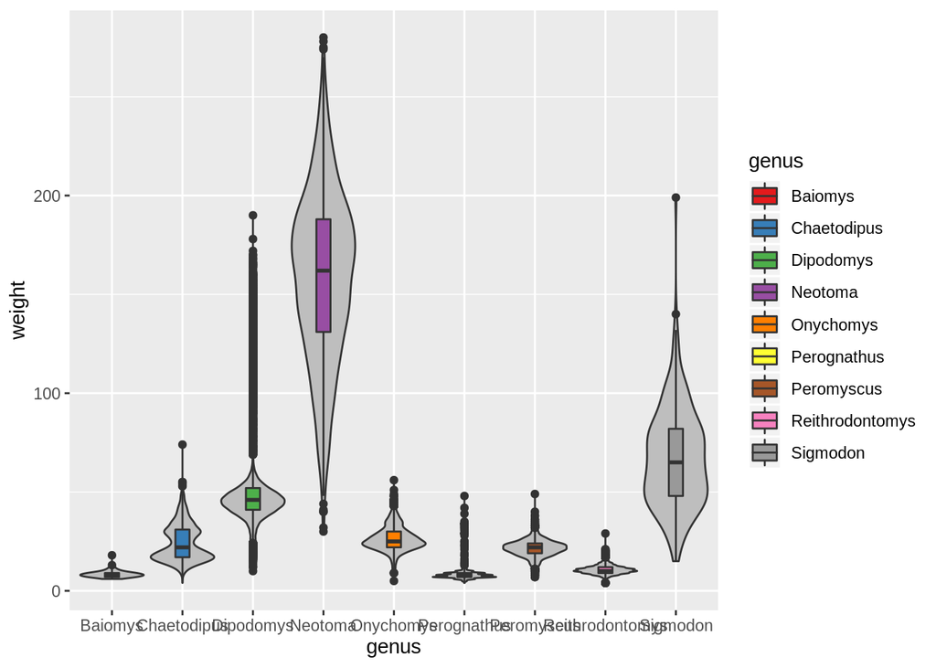

```r
ggplot(surveys_nomiss, aes(x = genus, y = weight)) +
  geom_violin(scale = "width", fill = "grey") +
  geom_boxplot(width = 0.2, aes(fill = genus)) +
  scale_fill_brewer(palette = "Set1")
```

You can see all the available palettes [here](https://r4ds.had.co.nz/graphics-for-communication.html#fig:brewer). Note that some palettes only have a limited number of colours and `ggplot` will give a warning if it has fewer colours available than categories in the data.

#### Change continuous fill/colour scales

Let’s get back to our scatterplot and colour the points by year of collection:

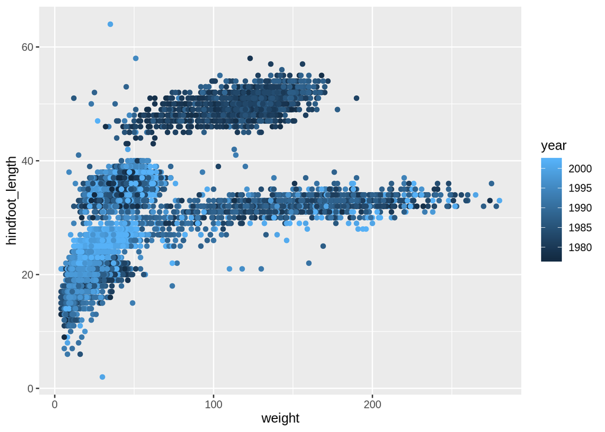

```r
ggplot(surveys_nomiss, aes(x = weight, y = hindfoot_length)) +
  geom_point(aes(colour = year))
```

Because `year` is a continuous variable, *ggplot* created a *gradient* colour scale.

We can change the default:

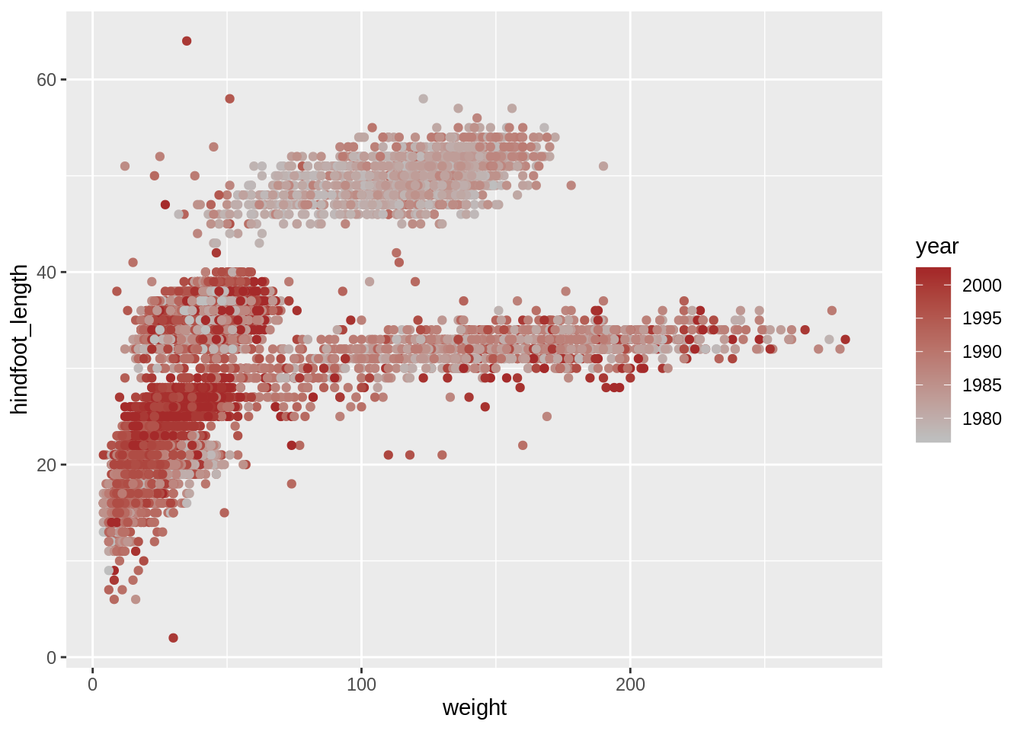

```r
ggplot(surveys_nomiss, aes(x = weight, y = hindfoot_length)) +
  geom_point(aes(colour = year)) +
  scale_colour_gradient(low = "grey", high = "brown")
```

For continuous colour scales we can use the [*viridis* palette](https://cran.r-project.org/web/packages/viridis/vignettes/intro-to-viridis.html), which has been developed to be colour-blind friendly and perceptually better:

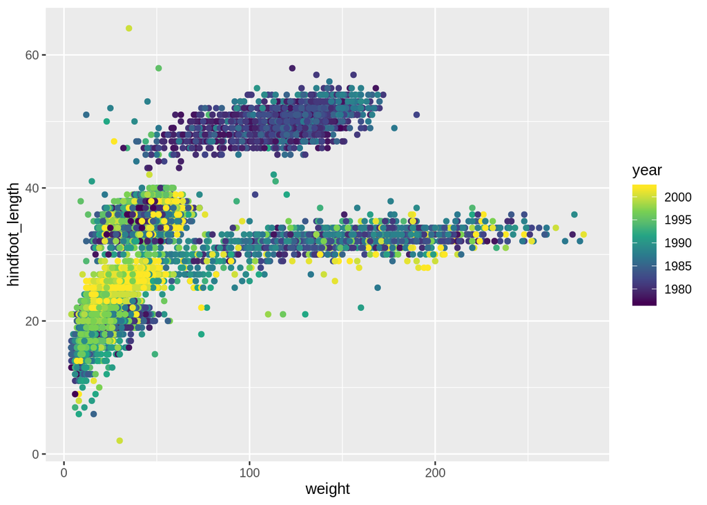

```r
ggplot(surveys_nomiss, aes(x = weight, y = hindfoot_length)) +
  geom_point(aes(colour = year)) +
  scale_colour_viridis_c()
```

# Key points

- To build a `ggplot2` graph you need to provide *data*, *aesthetics* and *geometries*.
- If you want to change an *aesthetic* of our graph **based on data**, include it **inside `aes()`**.
- If you want to **manually** change an *aesthetic* regardless of data then it goes **outside `aes()`**.
- You can overlay multiple geometries in the same graph, and control their aesthetics individually.
- You can adjust scales of your graph using `scale_*` family of functions.

Although we did not cover it here, make sure to choose a visualisation that is suitable for your data and question. See the [data-to-viz](https://www.data-to-viz.com/) website for great examples and advice!